# Detailed Cleaning, Filtering, and Processing

Bill Prisbrey

2024-10-02

**PURPOSE:** The purpose of this document is to describe in detail cleaning, filtering, and processing of proposals data.

**OBJECTIVES:**

1. Describe the initial data set.
2. Briefly list the cleaning and processing steps.
3. Describe the cleaning and processing steps in detail.
4. Describe the cleaned data set.

### **(1) INITIAL DATA DESCRIPTION**

As of 2 October 2024, the raw proposal data contains 114,022 rows with 64 columns. It ranges from the year 2007 to 2025. It contains 48,283 unique proposals submitted by 3,983 principal investigators from 761 organizations belonging to 44 college-level units.

### **(2) CLEANING AND PROCESSSING STEPS BRIEF**

1. Identify win/loss status per proposal.
2. Remove a proposal with unusual values.
3. Sum monetary values over all budget periods per proposal.
4. Filter out proposals with no budget listed (an empty value) or a total sponsor budget less than $150.
5. Include the name of the highest government agency for each federally-sponsored grant.
6. Filter out proposals before FY 2014 or after FY 2023.
7. Keep certain columns and remove others.

### **(3) CLEANING AND PROCESSSING STEPS DETAIL**

#### (a) Identify win/loss

A “win/loss” column is added to the proposal data based on the absence or presence of the proposal ID in the “awards” data.

Overall, this raw data has a 39.7% win rate.

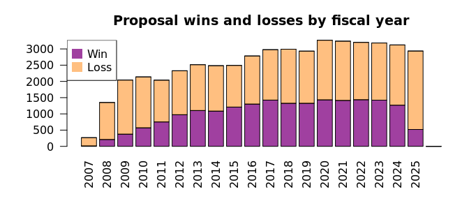

#### (b) Remove unusual proposal

A single proposal that is duplicated with “NA” values for college and organization for unclear reasons is removed.

Proposal with Multiple Organization Values Is Filtered Out

[output not shown]

#### (c) Sum monetary values

Out of 48,283 unique proposals, 26,103 (54%) have multiple rows.

These multiple rows per proposal reflect different monetary values over different budget periods. These varying values include the budget period itself, direct cost, facilities and administrative (F&A) cost, total sponsor budget, university cost share, and third-party cost share.

Monetary values for proposals that have multiple budget periods are summed over all periods per proposal. The monetary values are also calculated as a fraction of the “total sponsor budget”, and these fractions are merged back into the proposals data.

Budget periods typically (but not necessarily) reflect years, with a steep decline after five years.

Budget periods of -1 and 0 are filtered out. This consists of 75 proposals with a total sponsor budget of $53,622.

Count of proposals and median monetary values per budget period in raw proposal data

| Budget period | Proposal count | Direct cost | FA cost | Total budget | University cost share | Third pary cost share |
| --- | --- | --- | --- | --- | --- | --- |
| -1 | 72 | 0.0 | 0.0 | 0.0 | 0 | 0 |
| 0 | 3 | 0.0 | 0.0 | 0.0 | 0 | 0 |
| 1 | 48210 | 74356.5 | 18381.5 | 98845.5 | 0 | 0 |
| 2 | 26102 | 120097.5 | 41895.0 | 161792.0 | 0 | 0 |
| 3 | 19138 | 137006.0 | 49720.0 | 187391.5 | 0 | 0 |
| 4 | 11401 | 229186.0 | 84536.0 | 310285.0 | 0 | 0 |
| 5 | 8612 | 250000.0 | 103279.0 | 372500.0 | 0 | 0 |
| 6 | 286 | 112290.5 | 32993.0 | 162796.5 | 0 | 0 |
| 7 | 128 | 190018.0 | 82485.5 | 282500.5 | 0 | 0 |
| 8 | 38 | 152760.5 | 56925.5 | 208943.5 | 0 | 0 |
| 9 | 15 | 195982.0 | 67690.0 | 301812.0 | 0 | 0 |
| 10 | 13 | 190161.0 | 69514.0 | 292848.0 | 0 | 0 |
| 11 | 2 | 179879.0 | 88140.5 | 268019.5 | 0 | 0 |
| 12 | 2 | 197352.0 | 96702.5 | 294054.5 | 0 | 0 |

### (d) Remove proposals with low and missing budgets

Proposals with total sponsor budget values less than $150 or with no value (“NA”) are filtered out. This removes 925 proposals (2%) with zero or NA values and 1,165 proposals (2%) with values between $0 and $150.

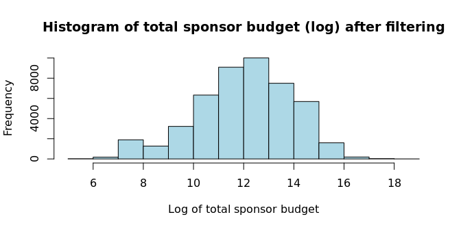

### (e) Include federal agencies

The names of sponsoring federal agencies are included.

Table of proposals per government agency

| Agency | Count |
| --- | --- |
| DHS | 33 |
| DOC | 122 |
| DOD | 1343 |
| DOE | 1424 |
| DOI | 228 |
| DOJ | 74 |
| DOL | 15 |
| DOS | 39 |
| DOT | 64 |
| ED | 175 |
| HHS | 10696 |
| HUD | 11 |
| NASA | 489 |
| NSF | 5338 |
| OTHER | 400 |
| USDA | 130 |
| USDT | 1 |
| VA | 2101 |
| NA | 25527 |

### (f) Remove some fiscal years

Proposals before fiscal year 2014 or after fiscal year 2023 are excluded. Missing values (“NA”) are also filtered out.

The proposals (5,558) with missing values in the other “date” columns are kept and will be managed with feature engineering and imputed values.

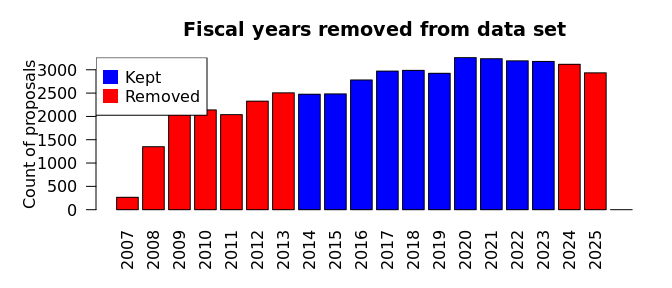

### (g) Select columns

Certain columns are kept and others are excluded. Many of the discarded columns are repetitive (representing an identification number where the name was kept instead). Other discarded columns may represent a “data leak” that contains information about whether the proposal was won (such as “PROPOSAL_STATUS”). Other columns (“PROPOSAL_PI_FACULTY_LINE_CAREER_BREAKOUT” and “PROPOSAL_PI_APPOINTMENT_SNAPSHOT_DT”) have a very high proportion of missing values.

Kept columns

| Kept column names |
| --- |
| PROPOSAL_ID |
| win |
| PROPOSAL_DIRECT_COST |
| PROPOSAL_FA_COST |
| PROPOSAL_TOTAL_SPONSOR_BUDGET |
| PROPOSAL_UNIVERSITY_COSTSHARE |
| PROPOSAL_3RD_PARTY_COSTSHARE |
| PROPOSAL_DIRECT_COST_prop |
| PROPOSAL_FA_COST_prop |
| PROPOSAL_UNIVERSITY_COSTSHARE_prop |
| PROPOSAL_3RD_PARTY_COSTSHARE_prop |
| PROPOSAL_SHORT_TITLE |
| PROPOSAL_TYPE |
| PROPOSAL_PURPOSE |
| PROPOSAL_RECIPIENT_FUNDING_TYPE |
| PROPOSAL_COST_SHARE_INDICATOR |
| PROPOSAL_FANDA_WAIVER_INDIVATOR |
| PROPOSAL_FANDA_OFF_CAMPUS_RATE_INDICATOR |
| PROPOSAL_UPLOAD_DATE_FISCAL_YEAR |
| PROPOSAL_PI_EMPLID |
| PROPOSAL_PI_NAME |
| PROPOSAL_PI_APPOINTMENT_DEPT |
| PROPOSAL_PI_APPOINTMENT_COLLEGE |
| PROPOSAL_PI_ACADEMIC_RANK |
| PROPOSAL_PI_TENURE_STATUS |
| PROPOSAL_PI_FACULTY_CATEGORY |
| PROPOSAL_PI_FACULTY_SUBCATEGORY |
| PROPOSAL_PI_ACADEMIC_RANK_LEVEL |
| PROPOSAL_PI_RANK_SORTED |
| PROPOSAL_PI_FACULTY_LINE_SORTED |
| PROPOSAL_ORG |
| PROPOSAL_DEPT |
| PROPOSAL_COLLEGE |
| VPR_PROPOSAL_COLLEGE |
| PROPOSAL_VP |
| VPR_PROPOSAL_VP |
| PROPOSAL_SPONSOR_ID |
| PROPOSAL_SPONSOR_NAME |
| PROPOSAL_SPONSOR_TYPE_CODE |
| PROPOSAL_SPONSOR_TYPE |
| PROPOSAL_IACUC_IRB_DIM_KEY |
| PROPOSAL_SPO_EMPLID |
| PROPOSAL_SPO_NAME |
| PROPOSAL_CREATION_DATE |
| PROPOSAL_OSP_RECEIVED_DATE |
| PROPOSAL_OSP_REVIEW_DATE |
| PROPOSAL_UPLOAD_DATE |
| PROPOSAL_PROJECT_START_DATE |
| PROPOSAL_PROJECT_END_DATE |
| PROPOSAL_SPONSOR_DUE_DATE |
| HIGHEST_GOVERNMENT_AGENCY_ACRONYM |
| NEXT_HIGHEST_GOVERNMENT_AGENCY_ACRONYM |

Discarded columns

| Discarded column names |
| --- |
| EPROPOSAL_DIM_KEY |
| PROPOSAL_TYPE_CODE |
| PROPOSAL_STATUS_CODE |
| PROPOSAL_STATUS |
| PROPOSAL_PURPOSE_CODE |
| PROPOSAL_RECIPIENT_FUNDING_TYPE_CODE |
| PROPOSAL_BUDGET_PERIOD |
| PROPOSAL_PI_IS_CURRENT_UU_EMP |
| PROPOSAL_PI_APPOINTMENT_DEPT_ID |
| PROPOSAL_PI_APPOINTMENT_COLLEGE_ID |
| PROPOSAL_PI_ACADEMIC_RANK_CD |
| PROPOSAL_PI_FACULTY_LINE_CAREER_BREAKOUT |
| PROPOSAL_PI_APPOINTMENT_SNAPSHOT_DT |
| PROPOSAL_ORGID |
| PROPOSAL_DEPTID |
| PROPOSAL_COLLEGEID |
| VPR_PROPOSAL_COLLEGEID |
| PROPOSAL_VPID |
| VPR_PROPOSAL_VPID |

### **(4) CLEANED DATA DESCRIPTION**

The cleaned proposal data contains 28,789 rows with 52 columns. It ranges from the fiscal year 2014 to 2023. It contains 28,789 unique proposals submitted by 2,937 principal investigators from 631 organizations belonging to 42 college-level units.

Overall, 46% of the proposals won.

Data summary

| Name | cleanData |
| --- | --- |
| Number of rows | 28789 |
| Number of columns | 52 |
| _______________________ |  |
| Column type frequency: |  |
| factor | 36 |
| numeric | 9 |
| POSIXct | 7 |
| ________________________ |  |
| Group variables | None |

**Variable type: factor**

| skim_variable | n_missing | complete_rate | ordered | n_unique | top_counts |
| --- | --- | --- | --- | --- | --- |
| PROPOSAL_ID | 0 | 1 | FALSE | 28789 | 100: 1, 100: 1, 100: 1, 100: 1 |
| win | 0 | 1 | FALSE | 2 | los: 15680, win: 13109 |
| PROPOSAL_SHORT_TITLE | 0 | 1 | FALSE | 27634 | Ne: 20, New: 20, CAR: 13, NS: 9 |
| PROPOSAL_TYPE | 0 | 1 | FALSE | 6 | New: 25550, Res: 2109, Com: 628, Pre: 305 |
| PROPOSAL_PURPOSE | 0 | 1 | FALSE | 5 | Res: 23352, Cli: 2813, Oth: 1818, Ins: 803 |
| PROPOSAL_RECIPIENT_FUNDING_TYPE | 0 | 1 | FALSE | 4 | PI : 27278, Fel: 865, Fel: 643, (No: 3 |
| PROPOSAL_COST_SHARE_INDICATOR | 0 | 1 | FALSE | 2 | Not: 28225, Cos: 564 |
| PROPOSAL_FANDA_WAIVER_INDIVATOR | 0 | 1 | FALSE | 3 | Wai: 27858, Wai: 929, Not: 2 |
| PROPOSAL_FANDA_OFF_CAMPUS_RATE_INDICATOR | 0 | 1 | FALSE | 2 | On : 26014, Off: 2775 |
| PROPOSAL_UPLOAD_DATE_FISCAL_YEAR | 0 | 1 | FALSE | 10 | 202: 3210, 202: 3195, 202: 3133, 202: 3127 |
| PROPOSAL_PI_EMPLID | 0 | 1 | FALSE | 2937 | 003: 211, 001: 105, 000: 102, 002: 96 |
| PROPOSAL_PI_NAME | 0 | 1 | FALSE | 2937 | LON: 211, SAM: 105, CAS: 102, BON: 96 |
| PROPOSAL_PI_APPOINTMENT_DEPT | 0 | 1 | FALSE | 113 | NNN: 13264, Int: 2441, Ped: 1236, Ele: 689 |
| PROPOSAL_PI_APPOINTMENT_COLLEGE | 0 | 1 | FALSE | 37 | NNN: 13264, Sch: 8404, Col: 3049, Col: 1414 |
| PROPOSAL_PI_ACADEMIC_RANK | 0 | 1 | FALSE | 34 | NNN: 13560, Pro: 4996, Ass: 3553, Ass: 3299 |
| PROPOSAL_PI_TENURE_STATUS | 0 | 1 | FALSE | 4 | NNN: 13571, Ten: 7640, Non: 4563, Not: 3015 |
| PROPOSAL_PI_FACULTY_CATEGORY | 0 | 1 | FALSE | 8 | NNN: 13571, Ten: 9967, Car: 2247, Ten: 2227 |
| PROPOSAL_PI_FACULTY_SUBCATEGORY | 0 | 1 | FALSE | 10 | NNN: 13571, Ten: 6254, Ten: 4563, Cli: 1472 |
| PROPOSAL_PI_ACADEMIC_RANK_LEVEL | 0 | 1 | FALSE | 5 | NNN: 13571, Pro: 5862, Ass: 4911, Ass: 4354 |
| PROPOSAL_PI_RANK_SORTED | 0 | 1 | FALSE | 6 | NNN: 13560, Pro: 5850, Ass: 4910, Ass: 4350 |
| PROPOSAL_PI_FACULTY_LINE_SORTED | 0 | 1 | FALSE | 6 | NNN: 13560, Ten: 12199, Car: 2784, Adj: 196 |
| PROPOSAL_ORG | 0 | 1 | FALSE | 631 | Ele: 1058, Mec: 933, HCI: 798, Civ: 748 |
| PROPOSAL_DEPT | 0 | 1 | FALSE | 131 | Int: 2916, Hun: 2752, Ped: 2093, Ele: 1058 |
| PROPOSAL_COLLEGE | 0 | 1 | FALSE | 42 | Spe: 12683, The: 4495, Col: 2834, Hun: 2752 |
| VPR_PROPOSAL_COLLEGE | 0 | 1 | FALSE | 24 | Spe: 12683, The: 4495, Col: 2834, Hun: 2752 |
| PROPOSAL_VP | 0 | 1 | FALSE | 10 | Sen: 15198, Sen: 10336, Uni: 2805, VP : 406 |
| VPR_PROPOSAL_VP | 0 | 1 | FALSE | 4 | Sen: 15198, Sen: 10336, OTH: 3250, NNN: 5 |
| PROPOSAL_SPONSOR_ID | 0 | 1 | FALSE | 3526 | 100: 3110, 101: 2697, 111: 955, 112: 709 |
| PROPOSAL_SPONSOR_NAME | 0 | 1 | FALSE | 3526 | NAT: 3110, DHH: 2697, VA : 955, NIH: 709 |
| PROPOSAL_SPONSOR_TYPE_CODE | 0 | 1 | FALSE | 10 | FED: 13443, IND: 4799, FDT: 4365, UNI: 3702 |
| PROPOSAL_SPONSOR_TYPE | 0 | 1 | FALSE | 10 | Fed: 13443, Ind: 4799, Ass: 4365, Uni: 3702 |
| PROPOSAL_IACUC_IRB_DIM_KEY | 0 | 1 | FALSE | 9 | 1: 11245, 9: 9714, 4: 4132, 6: 3013 |
| PROPOSAL_SPO_EMPLID | 0 | 1 | FALSE | 69 | 003: 2453, 001: 1850, 006: 1596, 001: 1549 |
| PROPOSAL_SPO_NAME | 0 | 1 | FALSE | 69 | BJO: 2453, ERN: 1850, DAL: 1596, GUD: 1549 |
| HIGHEST_GOVERNMENT_AGENCY_ACRONYM | 0 | 1 | FALSE | 19 | NNN: 15346, HHS: 6365, NSF: 3110, VA: 1383 |
| NEXT_HIGHEST_GOVERNMENT_AGENCY_ACRONYM | 0 | 1 | FALSE | 29 | NNN: 15346, NIH: 5963, NSF: 3110, VA: 1383 |

**Variable type: numeric**

| skim_variable | n_missing | complete_rate | mean | sd | p0 | p25 | p50 | p75 | p100 | hist |
| --- | --- | --- | --- | --- | --- | --- | --- | --- | --- | --- |
| PROPOSAL_DIRECT_COST | 0 | 1 | 491372.67 | 1677773.26 | 0 | 40000.00 | 150000.00 | 442017.00 | 153840637.00 | ▇▁▁▁▁ |
| PROPOSAL_FA_COST | 0 | 1 | 178075.47 | 431047.00 | 0 | 400.00 | 36365.00 | 157500.00 | 16469841.00 | ▇▁▁▁▁ |
| PROPOSAL_TOTAL_SPONSOR_BUDGET | 0 | 1 | 669448.14 | 2022026.64 | 151 | 49984.00 | 192495.00 | 600000.00 | 167639391.00 | ▇▁▁▁▁ |
| PROPOSAL_UNIVERSITY_COSTSHARE | 0 | 1 | 5701.90 | 153125.66 | 0 | 0.00 | 0.00 | 0.00 | 18366015.00 | ▇▁▁▁▁ |
| PROPOSAL_3RD_PARTY_COSTSHARE | 0 | 1 | 3689.95 | 306590.50 | 0 | 0.00 | 0.00 | 0.00 | 51053978.00 | ▇▁▁▁▁ |
| PROPOSAL_DIRECT_COST_prop | 0 | 1 | 0.78 | 0.14 | 0 | 0.66 | 0.73 | 0.91 | 1.00 | ▁▁▁▇▅ |
| PROPOSAL_FA_COST_prop | 0 | 1 | 0.22 | 0.14 | 0 | 0.09 | 0.27 | 0.34 | 1.00 | ▅▇▁▁▁ |
| PROPOSAL_UNIVERSITY_COSTSHARE_prop | 0 | 1 | 0.02 | 0.20 | 0 | 0.00 | 0.00 | 0.00 | 22.74 | ▇▁▁▁▁ |
| PROPOSAL_3RD_PARTY_COSTSHARE_prop | 0 | 1 | 0.00 | 0.07 | 0 | 0.00 | 0.00 | 0.00 | 9.23 | ▇▁▁▁▁ |

**Variable type: POSIXct**

| skim_variable | n_missing | complete_rate | min | max | median | n_unique |
| --- | --- | --- | --- | --- | --- | --- |
| PROPOSAL_CREATION_DATE | 0 | 1.00 | 2011-06-09 | 2023-06-29 | 2018-10-02 | 3119 |
| PROPOSAL_OSP_RECEIVED_DATE | 2 | 1.00 | 2012-01-31 | 2023-06-30 | 2018-10-22 | 3055 |
| PROPOSAL_OSP_REVIEW_DATE | 1 | 1.00 | 2011-06-09 | 2023-06-29 | 2018-10-12 | 3090 |
| PROPOSAL_UPLOAD_DATE | 0 | 1.00 | 2013-07-01 | 2023-06-30 | 2018-11-07 | 2514 |
| PROPOSAL_PROJECT_START_DATE | 1 | 1.00 | 2010-04-01 | 2024-10-01 | 2019-03-13 | 1623 |
| PROPOSAL_PROJECT_END_DATE | 3 | 1.00 | 2012-06-30 | 2038-09-30 | 2021-09-30 | 1723 |
| PROPOSAL_SPONSOR_DUE_DATE | 5555 | 0.81 | 2009-08-05 | 2024-07-13 | 2019-01-15 | 2960 |

Federal agencies

|  | HIGHEST_GOVERNMENT_AGENCY_ACRONYM | HIGHEST_GOVERNMENT_AGENCY | NEXT_HIGHEST_GOVERNMENT_AGENCY_ACRONYM | NEXT_HIGHEST_GOVERNMENT_AGENCY | SPONSOR_ID | SPONSOR_NAME |
| --- | --- | --- | --- | --- | --- | --- |
| 827 | DHS | DEPARTMENT OF HOMELAND SECURITY | DHS | DEPARTMENT OF HOMELAND SECURITY | 10204 | US DEPARTMENT OF HOMELAND SECURITY |
| 13352 | DHS | DEPARTMENT OF HOMELAND SECURITY | DHS | DEPARTMENT OF HOMELAND SECURITY | 10646 | DHS FEDERAL EMERGENCY MANAGEMENT AGENCY |
| 22 | DOC | DEPARTMENT OF COMMERCE | DOC | DEPARTMENT OF COMMERCE | 10092 | DOC NATL OCEANIC & ATMOSPHERIC ADMIN |
| 255 | DOC | DEPARTMENT OF COMMERCE | DOC | DEPARTMENT OF COMMERCE | 13558 | US DEPARTMENT OF COMMERCE |
| 315 | DOC | DEPARTMENT OF COMMERCE | DOC | DEPARTMENT OF COMMERCE | 10205 | DOC OFFICE OF NATL GEODETIC SURVEY |
| 539 | DOC | DEPARTMENT OF COMMERCE | DOC | DEPARTMENT OF COMMERCE | 10093 | DOC NATIONAL MARINE FISHERIES SVC |
| 730 | DOC | DEPARTMENT OF COMMERCE | DOC | DEPARTMENT OF COMMERCE | 10091 | DOC ECONOMIC DEVELOPMENT ADMINISTRATION |
| 2581 | DOC | DEPARTMENT OF COMMERCE | DOC | DEPARTMENT OF COMMERCE | 15026 | DOC NATIONAL WEATHER SERVICE |
| 3102 | DOC | DEPARTMENT OF COMMERCE | DOC | DEPARTMENT OF COMMERCE | 14959 | DOC NATL INST OF STANDARDS AND TECH |
| 6955 | DOC | DEPARTMENT OF COMMERCE | DOC | DEPARTMENT OF COMMERCE | 11130 | DOC NATL TELECOM INFO ADM |
| 17128 | DOC | DEPARTMENT OF COMMERCE | DOC | DEPARTMENT OF COMMERCE | 00017677 | DOC US CENSUS BUREAU |
| 6 | DOD | DEPARTMENT OF DEFENSE | NAVY | NAVY | 10117 | OFFICE OF NAVAL RESEARCH |
| 37 | DOD | DEPARTMENT OF DEFENSE | ARMY | ARMY | 14063 | ARMY MEDICAL RESEARCH ACQUISITION ACTVTY |
| 40 | DOD | DEPARTMENT OF DEFENSE | GENERAL DOD | GENERAL DOD | 10095 | US DEPARTMENT OF DEFENSE |
| 65 | DOD | DEPARTMENT OF DEFENSE | ARMY | ARMY | 10109 | ARMY RESEARCH OFFICE |
| 107 | DOD | DEPARTMENT OF DEFENSE | GENERAL DOD | GENERAL DOD | 10698 | DOD DEFENSE ADVANCED RESRCH PRJCTS AGCY |
| 134 | DOD | DEPARTMENT OF DEFENSE | AIR FORCE | AIR FORCE | 10098 | AIR FORCE OFFICE OF SCIENTIFIC RESEARCH |
| 266 | DOD | DEPARTMENT OF DEFENSE | ARMY | ARMY | 10108 | ARMY MEDICAL RESEARCH & MATERIEL COMMAND |
| 280 | DOD | DEPARTMENT OF DEFENSE | GENERAL DOD | GENERAL DOD | 10110 | DOD MISSILE DEFENSE AGENCY |
| 421 | DOD | DEPARTMENT OF DEFENSE | ARMY | ARMY | 10102 | US ARMY |
| 571 | DOD | DEPARTMENT OF DEFENSE | GENERAL DOD | GENERAL DOD | 14920 | DOD DEFENSE THREAT REDUCTION AGENCY |
| 587 | DOD | DEPARTMENT OF DEFENSE | NSA | NATIONAL SECURITY AGENCY | 10125 | NATIONAL SECURITY AGENCY |
| 1022 | DOD | DEPARTMENT OF DEFENSE | AIR FORCE | AIR FORCE | 10099 | AIR FORCE RESEARCH LABORATORY |
| 1042 | DOD | DEPARTMENT OF DEFENSE | NAVY | NAVY | 10510 | NAVAL SURFACE WARFARE CENTER |
| 1213 | DOD | DEPARTMENT OF DEFENSE | GENERAL DOD | GENERAL DOD | 10348 | DOD STRATEGIC ENVRNMNTL RSRCH & DEV PRGM |
| 1974 | DOD | DEPARTMENT OF DEFENSE | GENERAL DOD | GENERAL DOD | 10123 | NATIONAL GEOSPATIAL-INTELLIGENCE AGCY |
| 2025 | DOD | DEPARTMENT OF DEFENSE | NAVY | NAVY | 10118 | NAVAL RESEARCH LABORATORY |
| 2560 | DOD | DEPARTMENT OF DEFENSE | NAVY | NAVY | 10114 | US NAVY |
| 2739 | DOD | DEPARTMENT OF DEFENSE | NAVY | NAVY | 10115 | NAVAL AIR SYSTEMS COMMAND |
| 2940 | DOD | DEPARTMENT OF DEFENSE | AIR FORCE | AIR FORCE | 11336 | AIR FORCE HILL AIR FORCE BASE |

[output cut: 237 more lines]